```python
import numpy as np, pandas as pd, scipy.stats, sympy, matplotlib.pyplot as plt,matplotlib as mpl, math
from numpy import random_intel # Used to speed up deneration (~x10)
plt.rc('font', family='serif')
plt.rc('text', usetex=True)
mpl.rcParams['figure.dpi'] = 150
mpl.rcParams['savefig.dpi'] = 300
from IPython.display import display
from math import factorial
```

# Exercise 4

- Write a discrete event simulation program for a blocking system, i.e. a system with n service units and no waiting room.
- The arrival process is modelled as a Poisson process.
- Choose first the service time distribution as exponential.
- Record the fraction of blocked customers, and a confidence interval for this fraction.
- The programme should take the offered traffic and the number of service units as input parameters.

Example: n = 10, mean service time = 8 time units, mean time between customers = 1 time unit (corresponding to an offered traffic of 8 erlang), 10 x 10.000 customers.

First the eventlist of the simulation is set up as a class. There are two possible events: Arrival of a customer (arrive) and departure of a customer (depart). Whenever a customer arrives, another arriving customer is generated in the eventlist along with its corresponding arrival time based on the given probability distribution. It is then checked whether a service unit is available. If this is the case, a departing customer is generated in the eventlist along with its corresponding departure time, also based on the given probability distribution. If no service unit is available, the customer is rejected and stored as such. This continues until N=10.000 arriving customers have been generated.

```python
# Events defined
class events:
    def arrive():
        global blocked, clock, rejected, eventList, idle, numCustomers
        eventList.append((clock+customerTime(),1)) # Next arrival time
        numCustomers += 1

        if idle.any():
            i = np.where(idle)[0][0]
            idle[i] = False
            eventList.append((clock+serviceTime(),0,i)) # Departure time
        else:
            rejected += 1
            blocked.append(clock)

        eventList = sorted(eventList,key=lambda x: x[0])

    def depart(i):
        global idle

        idle[i] = True

# Blocking system program
def blockingSystem(numberOfServers,numberOfCustomers,timeService,timeCustomer,seed=10):
    global blocked, clock, rejected, eventList, idle, numCustomers, idle
    np.random_intel.seed(seed)
    eventList = [(0,1)]

    idle = np.ones(n)
    numCustomers = 0

    clock = 0
    rejected = 0
    blocked = []

    while numCustomers < N:
        event = eventList.pop(0)
        clock = event[0]
        if event[1] == 1:
            events.arrive()
        elif event[1] == 0:
            events.depart(event[2])

    return blocked, rejected, eventList

# Plot function
def plotRejects():
    y = [i for i in range(len(blocked)+1)]
    x = np.concatenate([[0],blocked])
    fig ,ax1 = plt.subplots(1,figsize =(10,5))
    fig.suptitle('Rejects')
    ax1.step(x,y,label  = 'Total rejects')
    ax1.set_xlabel('Customers')
    ax1.set_ylabel('Rejections')

    ax2 = ax1.twinx()
    plt.plot(x,y/(x+1)*100,'--',c='gray',label = 'Rate of rejects')
    ax2.set_ylabel('\% rejects')
    h1, l1 = ax1.get_legend_handles_labels()
    h2, l2 = ax2.get_legend_handles_labels()
    ax1.legend(h1+h2, l1+l2, loc = 4)
    plt.show()
```

```python
# Events defined
class events:
    def arrive():
        global blocked, clock, rejected, eventList, idle, numCustomers
        eventList.append((clock+customerTime(),1)) # Next arrival time
        numCustomers += 1

        if idle.any():
            i = np.where(idle)[0][0]
            idle[i] = False
            eventList.append((clock+serviceTime(),0,i)) # Departure time
        else:
            rejected += 1

        eventList = sorted(eventList,key=lambda x: x[0])

    def depart(i):
        global idle

        idle[i] = True

# Blocking system program
def blockingSystem(numberOfServers,numberOfCustomers,timeService,timeCustomer,seed=10):
    global blocked, clock, rejected, eventList, idle, numCustomers, clockCount, customersCount
    np.random_intel.seed(seed)
    eventList = [(0,1)]

    idle = np.ones(n)
    clock = 0
    numCustomers = 0
    rejected = 0
    clockCount = []
    customersCount = []
    blocked = []

    while numCustomers < N:
        event = eventList.pop(0)
        clock = event[0]
        clockCount.append(clock)
        if event[1] == 1:
            events.arrive()
        elif event[1] == 0:
            events.depart(event[2])
        customersCount.append(numCustomers)
        blocked.append(rejected)

    return blocked, rejected, eventList, clockCount, customersCount

# Plot function
def plotRejects():
    fig ,ax1 = plt.subplots(1,figsize =(10,5))
    fig.suptitle('Rejects')
    ax1.plot(clockCount,customersCount,label  = '# customers')
    ax1.set_xlabel('Time')
    ax1.set_ylabel('Customers')

    ax2 = ax1.twinx()
    plt.plot(clockCount,np.array(blocked)/np.array(customersCount)*100,'--',c='gray',label = 'Rate of rejects')
    ax2.set_ylabel('\% rejects')
    #h1, l1 = ax1.get_legend_handles_labels()
    #h2, l2 = ax2.get_legend_handles_labels()
    #ax1.legend(h1+h2, l1+l2, loc = 4)
    plt.show()
```

## Exponentially distributed times

The simulation is firstly done for the arrival process modelled as a Poisson process (arriving time is exponentially distributed) and the service time distribution as exponential.

```python
# Initialization
n = 10
N = 10000
timeService = 8
timeCustomer = 1
```

```
Percentage rejected: 12.13%
```

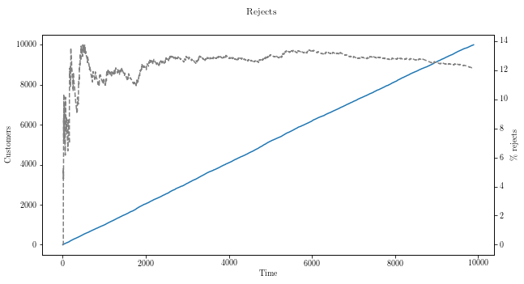

```python
customerTime = lambda: np.random_intel.exponential(timeCustomer)
serviceTime = lambda: np.random_intel.exponential(timeService)

blockingSystem(n,N,timeService,timeCustomer)
org = rejected/N

print("Percentage rejected: {:0.2f}%".format(rejected/N*100))

plotRejects()
```

From the above plot it is seen, that the rejection fraction reaches 12.13% after 10.000 customers. There also seems to be some equilibrium after a burn period of 2000 customers.

## Confidence limits based on sub-sample

- We want to estimate some quantity θ
- We obtain n different (independent) estimates $\hat{\theta}_i$ .
- The central limit theorem motivates us to construct the following confidence interval: \begin{equation} \bar{\theta}=\frac{\sum_{i=1}^n\hat{\theta}_i}{n}\quad s_\theta^2= \frac{1}{n-1}\left(\sum_{i=1}^n\hat{\theta}_i^2-n\bar{\theta}_i^2\right) \end{equation}

We thus generate 10 instances of 10.000 customers visiting to obtain $\bar{\theta}$ and the standard deviation $s_\theta$

```python
np.random_intel.seed(1)
rand = np.random_intel.randint(0,10000,size=10)
rarr=[]
for i in rand:
    _, r,_,_,_ =blockingSystem(n,N,timeService,timeCustomer,seed=i)
    rarr.append(r)
res = np.array(rarr)/N*100
theta = res.mean()
S_theta = 1/(n-1)*(sum([i**2 for i in res])-n*theta**2)

print("theta = {:0.4f}".format(theta))
print("s_theta = {:0.4f}".format(S_theta**(1/2)))
```

```
theta = 12.3370
s_theta = 0.3531
```

This allows us to calculate the confidence interval based on: \begin{equation} \left[\bar{\theta}+\frac{S_\theta}{\sqrt{n}}t_{\frac{\alpha}{2}}(n-1);\bar{\theta}+\frac{S_\theta}{\sqrt{n}}t_{1-\frac{\alpha}{2}}(n-1)\right] \end{equation} with $\alpha = 0.05$

```python
alpha = 0.05
lower,upper = theta + S_theta**(1/2)/n**(1/2)*scipy.stats.t.ppf([alpha/2,1-alpha/2],n-1)
print('Lower: {:0.4f}  Upper: {:0.4f}'.format(lower,upper))
```

```
Lower: 12.0844  Upper: 12.5896
```

The 95 % confidence interval is visualised below with the results of 10 simulations of rejected customers as simulated above:

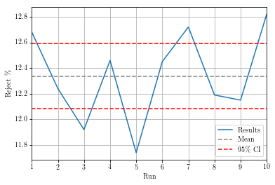

```python
plt.plot([i for i in range(1,11)],res,label = 'Results')
plt.plot([i for i in range(1,11)],[theta for _ in range(0,10)],'--',c='gray',label = 'Mean')
plt.plot([i for i in range(1,11)],[upper for _ in range(0,10)],'--',c='r',label = '95\% CI')
plt.plot([i for i in range(1,11)],[lower for _ in range(0,10)],'--',c='r')
plt.legend()
plt.xlabel('Run')
plt.ylabel('Reject \%')
plt.xlim([1,10])
plt.grid()
plt.show()
```

We see that half of the rejection fractions found in the simulations lies outside the confidence interval. Other distributions will be used to simulate this process.

## Erlang distribution

The erlang distribution is a special case of the gamma distribution where \begin{equation} \mu = \underbrace{\frac{1}{\lambda}}_{=\mu_{erlang}}=\underbrace{k\cdot \theta}_{=\mu_{gamma}} \end{equation} For k = 5 this yields:

```
Percentage rejected: 7.10%
```

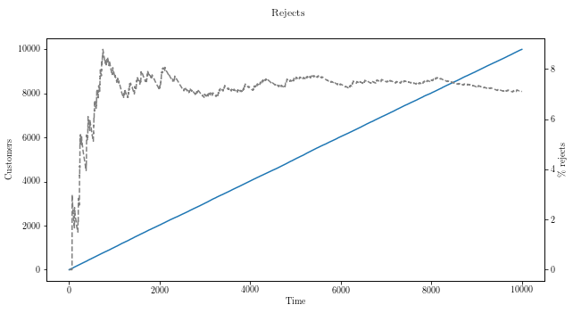

```python
k = 5
mu = 1
l = 1/mu
theta = mu/k
np.random_intel.seed(10)
np.random_intel.gamma(shape=k, scale=theta,size = 1)
customerTime= lambda: np.random_intel.gamma(shape=k, scale=theta)#events.set_cDistribution(customerTime1)

blockingSystem(n,N,timeService,timeCustomer)

print("Percentage rejected: {:0.2f}%".format(rejected/N*100))

plotRejects()
```

For k=5 it is seen that the rejection fraction ends at 7.1 % after 10,000 customers.

## Hyper-Exponential Distribution

The hyper-exponential distribution generates numbers based on two different exponential distributions with different probabilities of generating from each. Here, \begin{equation} p_1 = 0.8, \lambda_1 = 0.8333, p_2 = 0.2, \lambda_2 = 5.0 \end{equation} Below, the hyper-exponential distribution is defined as a function.

```python
p = [0.8,0.2]
l = [0.8333,5]

def hyper():
    i = np.random_intel.rand()
    if i<p[0]:
        return np.random_intel.exponential(l[0])
    else:
        return np.random_intel.exponential(l[1])
```

```
Percentage rejected: 5.01%
```

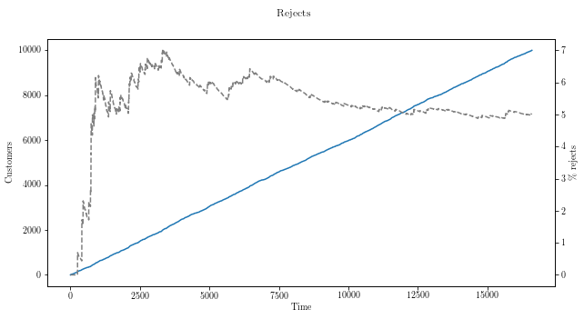

```python
customerTime = hyper

blockingSystem(n,N,timeService,timeCustomer)

print("Percentage rejected: {:0.2f}%".format(rejected/N*100))

plotRejects()
```

Here, the fraction of rejected customers are 5.01 %. There seems to be some sort of decay in this fraction as more customers visit, which indicates that a greater burn period is needed.

# Different service time distributions

## Constant service time

For a constant service time of 8 time units, rejection fraction looks as follows:

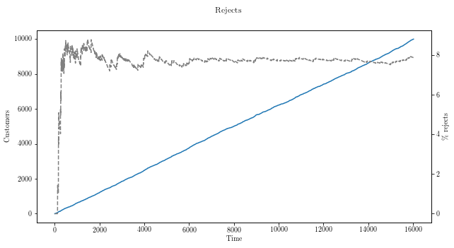

```python
serviceTime = lambda: 8
customerTime = hyper
#customerTime = lambda: np.random_intel.poisson(timeCustomer)
blockingSystem(n,N,timeService,timeCustomer)
plotRejects()
```

## Pareto service time

If the pareto distribution is used as the service time with k = 1.05, this yields:

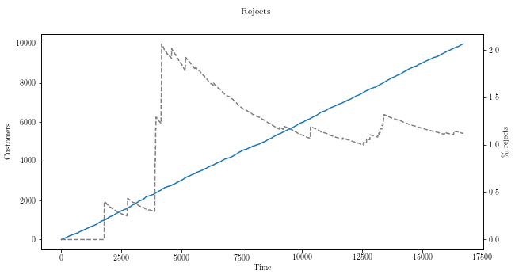

```python
serviceTime = lambda: np.random_intel.pareto(1.05)
customerTime = hyper
#customerTime = lambda: np.random_intel.poisson(timeCustomer)
blockingSystem(n,N,timeService,timeCustomer)
plotRejects()
```

And for k=2.05

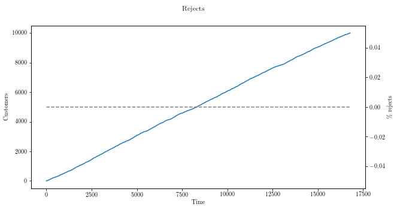

```python
serviceTime = lambda: np.random_intel.pareto(2.05)
customerTime = hyper
#customerTime = lambda: np.random_intel.poisson(timeCustomer)
blockingSystem(n,N,timeService,timeCustomer)
plotRejects()
```

# Theoretical Service time

- With arrival intensity $\lambda$ and mean service time $s$
- Define $A=\lambda s$ \begin{equation} B = P(n) = \frac{\frac{A^n}{n!}}{\sum_{i=0}^n\frac{A^i}{i!}} \end{equation}
- Valid for all service time distributions
- But arrival process has to be a Poisson process

Comparing this with the result from the first part of this exercise can hint the validity of the model

```python
s = 8
l = 1
A = l*s
n = 10
B = (A**n/factorial(n))/sum([A**i/factorial(i) for i in range(n+1)])
print("Empirical rejections: ", org)
print("Theoretical rejections: ", B)
print("Deviation of {:0.4f}%".format((org - B)/B*100))
```

```
Empirical rejections:  0.1213
Theoretical rejections:  0.12166106425295149
Deviation of -0.2968%
```